##### **Fig. C.25:** EOC SGP distributions for the HOSS and LOSS scores by norm group: Physical Science.

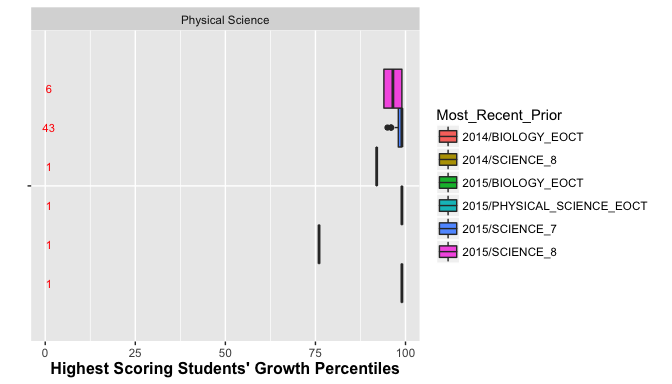

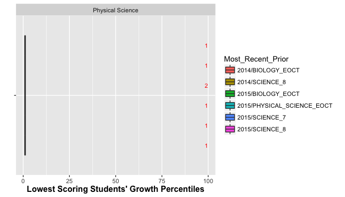

##### **Fig. C.26:** EOC SGP distributions for the HOSS and LOSS scores by norm group: Coordinate Algebra.

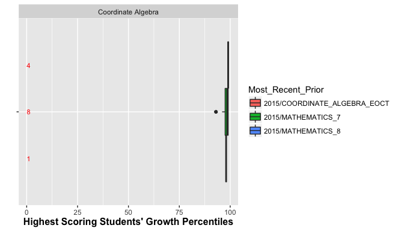

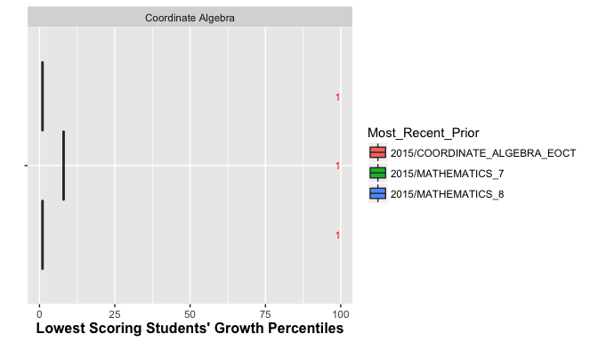

##### **Fig. C.27:** EOC SGP distributions for the HOSS and LOSS scores by norm group: Analytic Geometry.

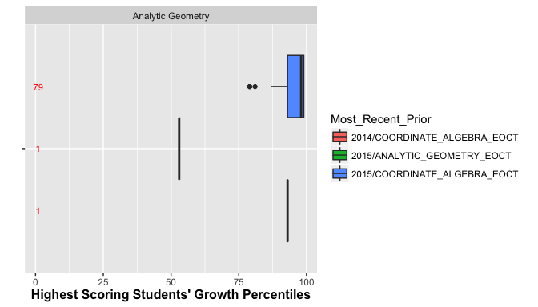

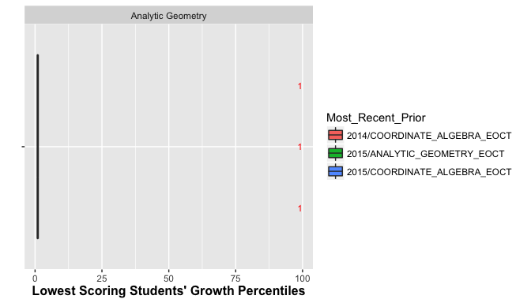

The Algebra I analysis using 7<sup>th</sup> Grade Math priors shows some minor ceiling issues. This is most likely due to the relatively high number of students attaining the HOSS in both years, which deflates the SGPs of the students with higher prior math scores. Although not as high as the ideal, these students’ SGPs are all on the higher end of the spectrum (above 70).

##### **Fig. C.28:** EOC SGP distributions for the HOSS and LOSS scores by norm group: Algebra I.

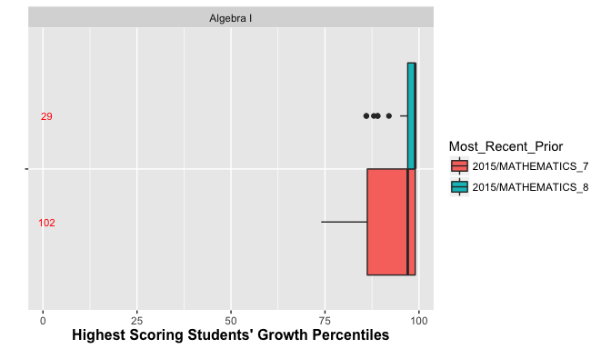

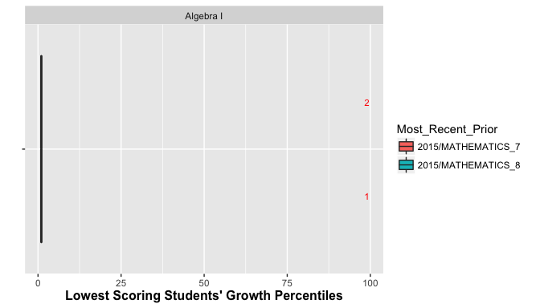

##### **Fig. C.29:** EOC SGP distributions for the HOSS and LOSS scores by norm group: Geometry.

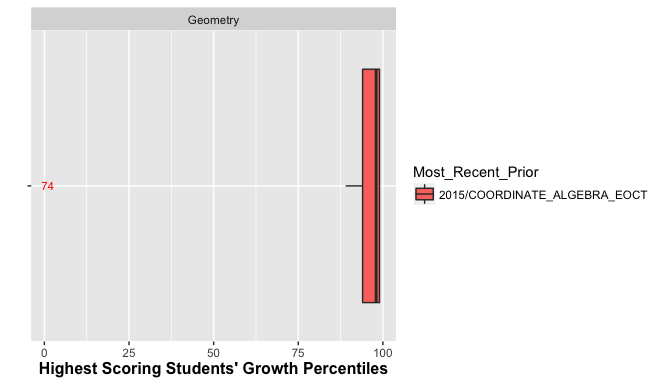

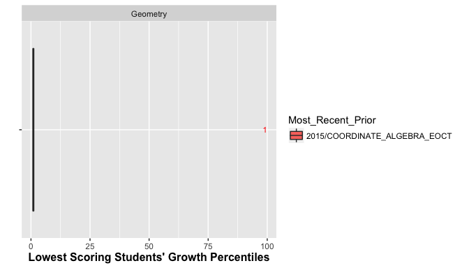

# 4 Discussion

Overall there is little evidence of floor or ceiling effects in the 2016 Georgia Milestones SGP analyses. Some scores for EOC test repeaters and skip year progressions suggest that a small number of minor problems may exist that could require changes. When ceiling or floor effects are encountered, there are several ways in which they can be “corrected” manually or analytically. These include (but not limited to):

1. Convert all students scoring at the HOSS (LOSS) to 99 (1).
2. Run SGP analyses with more granular scores. For example, many tests that use Item Response Theory (IRT) to analyse test results provide scaled scores that enforce an artificial ceiling (floor), but also have more granular achievement scores available (IRT *θ* estimates).
3. Leave the results without a correction.
[^1]: SIMEX measurement error corrected SGPs are used exclusively in this report.
[^2]: Note that many SGPs are estimated using more than one prior score, and therefore plots may show SGP results from multiple analyses and/or varying SGPs for identical score combinations.
[^3]: Produced using quantile regression similar to, but not the same as, that used in calculation of the SGPs.